# Analyze Twitter Networks

Install new libraries

```r
install.packages("networkD3") #for interactive network visualization
install.packages("igraph") #for network analysis
```

Load required libraries

```r
library(twitteR)
library(dplyr)
library(qdap)
library(networkD3)
library(igraph)
library(stringr)
```

Collect tweets through Twitter API

```r
setup_twitter_oauth("enter consumer key",
                    "enter consumer secret",
                    access_token="xxxxx",
                    access_secret="xxxx")

#collect recent 5000 tweets
alltweets <- twListToDF(searchTwitter("#MAGA", n=5000, lang=NULL,since=NULL, until=NULL,locale=NULL, geocode=NULL, sinceID=NULL, maxID=NULL,resultType=NULL, retryOnRateLimit=120))

#save tweets as .csv
write.csv(alltweets, "alltweets.csv")
```

Alternatively, you can use pre-saved data

```r
alltweets <- read.csv("alltweets.csv", header = TRUE)
```

```r
#Network analysis and visualization is computationally intensive. We will use only the first 500 tweets for demo.

alltweets<-alltweets[1:500,]

#split the data into two sets; one for retweet network and the other for mention network.

#create an edge-list for retweet network
sp = split(alltweets, alltweets$isRetweet)
rt = mutate(sp[['TRUE']], sender = substr(text, 5, regexpr(':', text) - 1))
el = as.data.frame(cbind(sender = tolower(rt$sender), receiver = tolower(rt$screenName)))
el = count(el, sender, receiver)
el[1:5,] #show the first 5 edges in the edgelist
```

[output not shown]

Based on the edge-list, create a retweet network.

```r
rt_graph <- graph_from_data_frame(d=el, directed=T)
```

Visualize the retweet network.

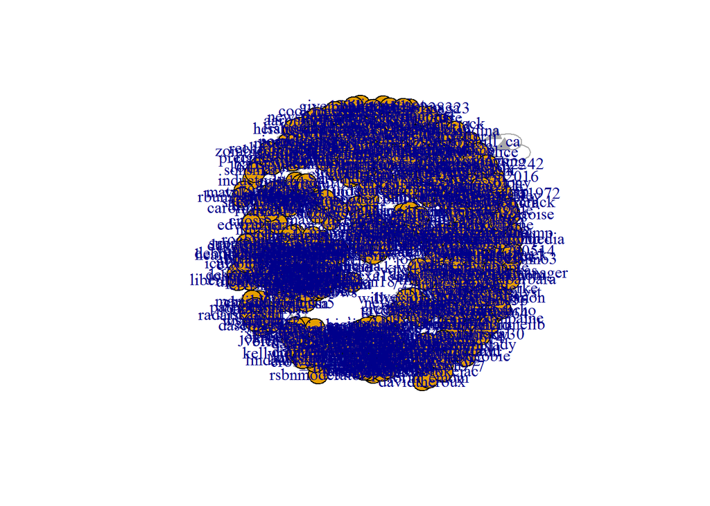

```r
glay = layout.fruchterman.reingold(rt_graph)
plot(rt_graph)
```

Isn’t it too messy? Let’s beautify it.

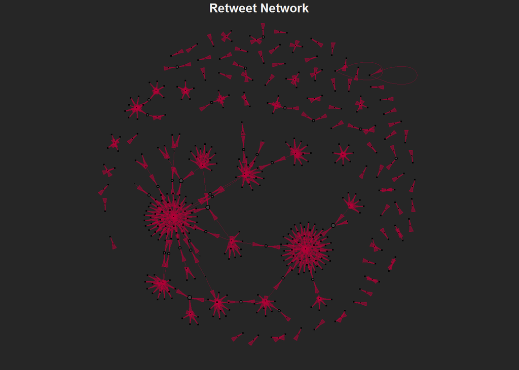

```r
glay = layout.fruchterman.reingold(rt_graph)
par(bg="gray15", mar=c(1,1,1,1))
plot(rt_graph, layout=glay,
     vertex.color="gray25",
     vertex.size=(degree(rt_graph, mode = "in")), #sized by in-degree centrality
     vertex.label = NA,
     edge.arrow.size=0.8,
     edge.arrow.width=0.5,
     edge.width=edge_attr(rt_graph)$n/10, #sized by edge weight
     edge.color=hsv(h=.95, s=1, v=.7, alpha=0.5))
title("Retweet Network", cex.main=1, col.main="gray95")
```

The above network visualization does not show vertex label. Let’s add a few lines to make the graph more informative. igraph is a very versatile by allowing a high degree of customization for visualization.

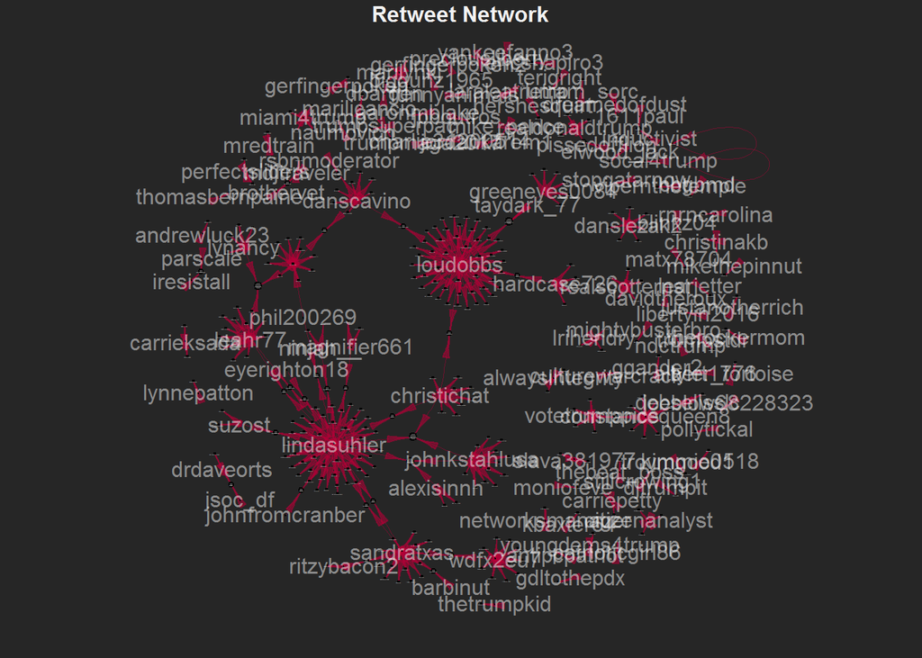

```r
glay = layout.fruchterman.reingold(rt_graph)
par(bg="gray15", mar=c(1,1,1,1))
plot(rt_graph, layout=glay,
     vertex.color="gray25",
     vertex.size=(degree(rt_graph, mode = "in")), #sized by in-degree centrality
     vertex.label.family="sans",
     vertex.shape="circle",  #can also try "square", "rectangle", etc. More in igraph manual
     vertex.label.color=hsv(h=0, s=0, v=.95, alpha=0.5),
     vertex.label.cex=(degree(rt_graph, mode = "in"))/300, #sized by in-degree centrality
     edge.arrow.size=0.8,
     edge.arrow.width=0.5,
     edge.width=edge_attr(rt_graph)$n/10, #sized by edge weight
     edge.color=hsv(h=.95, s=1, v=.7, alpha=0.5))
title("Retweet Network", cex.main=1, col.main="gray95")
```

Create an interactive visualization for the retweet network

```r
wc <- cluster_walktrap(rt_graph)
members <- membership(wc)
d3_rt <- igraph_to_networkD3(rt_graph, group = members)

forceNetwork(Links = d3_rt$links, Nodes = d3_rt$nodes,
             Source = 'source', Target = 'target',
             NodeID = 'name', Group = 'group')
```

[interactive chart not shown]

Calculate some network-level statistics for the retweet network

```r
ecount(rt_graph) #the number of edges
```

```
## [1] 388
```

```r
vcount(rt_graph) #the number of vertices
```

```
## [1] 460
```

```r
E(rt_graph)[1:50] #list the first 50 edges
```

```
## + 50/388 edges (vertex names):
##  [1] 1611paul       ->sonsmary        aaronmblake_   ->newspeakislies
##  [3] albert1776     ->jazzyjo20       alexisinnh     ->desimc46
##  [5] alexisinnh     ->elvisinoregon   alexisinnh     ->libertpartarian
##  [7] alwaysintegrity->alangib35785534 alwaysintegrity->tj1701a
##  [9] andrewluck23   ->donnas0818      antipcpatriot  ->gridironbeastyo
## [11] barbinut       ->zakerforce7     bfraser747     ->abqnicole
## [13] bfraser747     ->davejscorona    bfraser747     ->deborahhunnicu2
## [15] bfraser747     ->exx_treme       bfraser747     ->healthyheartfit
## [17] bfraser747     ->hinz_dale       bfraser747     ->icufromhere
## [19] bfraser747     ->rainestopper    bfraser747     ->rocofagi1
## + ... omitted several edges
```

```r
V(rt_graph)[1:50] #list the first 50 vertex ids
```

```
## + 50/460 vertices, named:
##  [1] 1611paul        aaronmblake_    albert1776      alexisinnh
##  [5] alwaysintegrity andrewluck23    antipcpatriot   barbinut
##  [9] bfraser747      biggunz1965     blinkz04        brothervet
## [13] carrieksada     carriepetty     cbgbmd          charlie31200514
## [17] christichat     christinakb     citizenanalyst  constancequeen8
## [21] culturewarcrack danscavino      danslezak2      davidtheroux
## [25] dbargen         debsellsslc     djtrumpit       drdaveorts
## [29] dreamedofdust   elwood_jack     ericshapiro3    eyerighton18
## [33] freedombill_ca  funnyanimals    gdltothepdx     gerfingerpoken
## [37] gerfingerpoken2 ggander2        greeneyes0084   hardcase726
## + ... omitted several vertices
```

```r
#Calculate density:The proportion of present edges from all possible edges in the network.
edge_density(rt_graph, loops=F) #for an undirected network
```

```
## [1] 0.001837643
```

```r
ecount(rt_graph)/(vcount(rt_graph)*(vcount(rt_graph)-1)) #for a directed network
```

```
## [1] 0.001837643
```

```r
#Calculate reciprocity:The proportion of reciprocated ties (for a directed network).
reciprocity(rt_graph)
```

```
## [1] 0
```

```r
#Calculate centralization
centr_degree(rt_graph, mode = c("in"), loops = TRUE,normalized = TRUE)$centralization
```

```
## [1] 0.004698304
```

```r
#Calculate transitivity:the probability that the neighbors of a vertex are connected.
transitivity(rt_graph, type="local")
```

```
##   [1] NaN NaN NaN   0   0 NaN NaN NaN   0 NaN NaN NaN   0   0 NaN NaN   0
##  [18]   0   0   0 NaN   0   0 NaN NaN   0 NaN   0   0 NaN NaN NaN   0 NaN
##  [35] NaN   0 NaN NaN   0   0 NaN NaN NaN NaN NaN   0 NaN NaN NaN NaN NaN
##  [52]   0 NaN   0   0 NaN NaN NaN   0   0   0   0 NaN   0 NaN   0 NaN   0
##  [69]   0 NaN   0 NaN NaN   0 NaN NaN NaN   0 NaN NaN   0   0 NaN NaN   0
##  [86]   0   0   0 NaN NaN   0   0 NaN NaN NaN   0 NaN NaN NaN NaN NaN NaN
## [103] NaN NaN NaN   0 NaN NaN   0   0 NaN   0   0 NaN NaN NaN   0 NaN NaN
## [120] NaN NaN NaN   0 NaN NaN NaN NaN NaN   0 NaN NaN NaN NaN   0 NaN NaN
## [137] NaN   0 NaN NaN NaN NaN NaN   0 NaN NaN NaN   0 NaN NaN   0 NaN NaN
## [154]   0 NaN NaN NaN NaN NaN NaN NaN   0 NaN NaN   0 NaN NaN NaN NaN NaN
## [171] NaN   0 NaN NaN NaN NaN NaN NaN   0 NaN NaN NaN NaN NaN NaN NaN NaN
## [188]   0 NaN NaN   0 NaN NaN NaN NaN NaN   0 NaN NaN NaN NaN NaN NaN   0
## [205] NaN NaN NaN NaN NaN NaN NaN NaN NaN NaN   0 NaN   0 NaN   0 NaN NaN
## [222] NaN NaN NaN NaN NaN NaN NaN NaN NaN NaN   0 NaN NaN NaN NaN NaN NaN
## [239] NaN NaN NaN NaN NaN NaN NaN NaN NaN   0 NaN NaN NaN   0 NaN NaN NaN
## [256] NaN NaN NaN NaN NaN NaN NaN NaN NaN NaN NaN NaN NaN NaN NaN NaN NaN
## [273] NaN NaN   0 NaN   0 NaN   0 NaN   0 NaN NaN NaN NaN NaN NaN NaN   0
## [290] NaN NaN NaN   0 NaN NaN NaN NaN NaN NaN NaN NaN NaN NaN NaN NaN NaN
## [307] NaN NaN NaN NaN NaN NaN NaN NaN NaN NaN NaN NaN NaN NaN NaN NaN NaN
## [324] NaN NaN NaN NaN NaN NaN NaN NaN NaN NaN NaN NaN NaN NaN NaN NaN NaN
## [341] NaN NaN NaN NaN NaN NaN NaN NaN NaN NaN NaN NaN NaN NaN NaN NaN NaN
## [358] NaN NaN NaN NaN NaN NaN NaN NaN NaN NaN NaN NaN NaN NaN NaN NaN NaN
## [375] NaN NaN NaN NaN NaN NaN NaN NaN NaN NaN NaN NaN NaN NaN NaN NaN NaN
## [392] NaN NaN NaN NaN   0 NaN NaN NaN NaN NaN NaN NaN NaN NaN NaN NaN NaN
## [409]   0 NaN   0 NaN NaN NaN NaN NaN NaN NaN NaN NaN NaN NaN NaN NaN NaN
## [426] NaN NaN NaN NaN NaN NaN NaN NaN NaN NaN NaN NaN NaN NaN NaN NaN NaN
## [443] NaN NaN NaN NaN NaN NaN NaN NaN NaN NaN NaN NaN NaN NaN NaN NaN NaN
## [460] NaN
```

```r
#Calculate the length of the longest path between two vertices in the network
diameter(rt_graph, directed=F, weights=NA)
```

```
## [1] 12
```

Some vertex-level statistics (based on the retweet network)

```r
#Calculate in-degree centrality
indegree <- sort(degree(rt_graph,mode = "in"),decreasing = TRUE)
indegree[1:20] #show the top vertices by in-degree
```

```
##   elvisinoregon    truthstation    susihoffman5  jamesedgriffin
##               3               3               3               3
##        sonsmary     zakerforce7       hinz_dale elisabethphili1
##               2               2               2               2
##      gconsidder     jkelley2836          odcusa        branumsr
##               2               2               2               2
##      joycep7777     crowebar_67  starra78811933      jwaters142
##               2               2               2               2
##         mllnola deplorabletexa1      trailschap cookingconquest
##               2               2               2               2
```

```r
#Calculate out-degree
outdegree <- sort(degree(rt_graph,mode = "out"),decreasing = TRUE)
outdegree[1:20] #show the top vertices by out-degree
```

```
##     lindasuhler        loudobbs      sandratxas         leahr77
##              62              54              19              16
##   johnkstahlusa      bfraser747     christichat        wdfx2eu7
##              14              12              11              11
##      danscavino constancequeen8      danslezak2   greeneyes0084
##              10               9               7               7
##     hardcase726         lvnancy  realscotternst   votetrumppics
##               5               5               5               5
##       marilynkj     miami4trump realdonaldtrump      alexisinnh
##               4               4               4               3
```

```r
#Calculate betweenness centrality
bt <- sort(betweenness(rt_graph, directed=F, weights=NA), decreasing = TRUE)
bt[1:20] #show the top vertices by betweenness centrality
```

```
##    lindasuhler       loudobbs    christichat    jkelley2836     sandratxas
##      20567.833      13871.533      11100.167       9763.533       6905.500
##   susihoffman5         odcusa     bfraser747        leahr77     danscavino
##       6717.167       4590.833       4474.667       3871.967       3618.667
##       erengwam         jc3me2  johnkstahlusa      hinz_dale       flexi215
##       3328.000       3328.000       2918.667       2808.667       2698.000
##     phil200269      axlfoley1 starra78811933       wdfx2eu7 jamesedgriffin
##       2596.000       2530.000       2371.000       2355.000       1871.000
```

```r
#Calculate closeness centrality: measures how many steps is required to access every other vertex from a given vertex
cc <- sort(closeness(rt_graph, mode="all", weights=NA), decreasing = TRUE)
cc[1:20] #show the top vertices by closeness centrality
```

```
##     lindasuhler    susihoffman5          odcusa     christichat
##    9.891295e-06    9.886405e-06    9.883865e-06    9.880056e-06
##        erengwam          jc3me2       rhinonewt   txchiks4trump
##    9.874105e-06    9.874105e-06    9.873910e-06    9.873910e-06
##        flexi215     jkelley2836   elvisinoregon          dwulke
##    9.873033e-06    9.872935e-06    9.870986e-06    9.868454e-06
##    lawdawgseven     mikehotchky deplorabletexa1      noisyhill1
##    9.868454e-06    9.868454e-06    9.868064e-06    9.868064e-06
##        loudobbs aadvantagepaint       absabella         adboa95
##    9.867967e-06    9.867869e-06    9.867869e-06    9.867869e-06
```

```r
#Calculate eigenvector centrality: connectivity with highly connected neighbors
ec <- eigen_centrality(rt_graph, directed=T, weights=NA)
sort(ec$vector)[1:20] #show the top vertices by eigenvector centrality centrality
```

```
##        1611paul    aaronmblake_      albert1776      alexisinnh
##               0               0               0               0
## alwaysintegrity    andrewluck23   antipcpatriot        barbinut
##               0               0               0               0
##      bfraser747     biggunz1965        blinkz04      brothervet
##               0               0               0               0
##     carrieksada     carriepetty          cbgbmd charlie31200514
##               0               0               0               0
##     christichat     christinakb  citizenanalyst constancequeen8
##               0               0               0               0
```

Find hubs and authorities. Hubs: lots outgoing edges; Authorities: lots incoming edges.

```r
hs <- hub_score(rt_graph, weights=NA)$vector
as <- authority_score(rt_graph, weights=NA)$vector

sort(hs, decreasing = TRUE)[1:20] #show the top 20 vertices by hub score
```

```
##     lindasuhler      sandratxas         leahr77   johnkstahlusa
##    1.000000e+00    4.607487e-02    4.308313e-02    4.245399e-02
##     christichat      alexisinnh    magnifier661        ninjah__
##    3.978244e-02    1.753206e-02    1.681807e-02    1.681807e-02
##          suzost      phil200269    eyerighton18 johnfromcranber
##    1.681807e-02    1.653990e-02    1.627078e-02    1.627078e-02
##        loudobbs        wdfx2eu7      bfraser747         lvnancy
##    4.744485e-03    8.953555e-04    8.710917e-04    7.649553e-04
##     ritzybacon2        barbinut      danscavino   greeneyes0084
##    7.620737e-04    7.496742e-04    1.070784e-04    8.696554e-05
```

```r
sort(as, decreasing = TRUE)[1:20] #show the top 20 vertices by authority score
```

```
##    susihoffman5   elvisinoregon        erengwam          jc3me2
##       1.0000000       0.9794404       0.9665863       0.9665863
##       rhinonewt   txchiks4trump          odcusa          dwulke
##       0.9638219       0.9638219       0.9607720       0.9395526
##    lawdawgseven     mikehotchky        flexi215 deplorabletexa1
##       0.9395526       0.9395526       0.9392956       0.9390469
##      noisyhill1 aadvantagepaint       absabella         adboa95
##       0.9390469       0.9240125       0.9240125       0.9240125
##       agree1967      az49ersfan    azblacksheep        blawatid
##       0.9240125       0.9240125       0.9240125       0.9240125
```

Find clusters

```r
cliques(rt_graph)[1:10]
```

```
## [[1]]
## + 1/460 vertex, named:
## [1] 1611paul
##
## [[2]]
## + 1/460 vertex, named:
## [1] aaronmblake_
##
## [[3]]
## + 1/460 vertex, named:
## [1] albert1776
##
## [[4]]
## + 1/460 vertex, named:
## [1] alexisinnh
##
## [[5]]
## + 1/460 vertex, named:
## [1] alwaysintegrity
##
## [[6]]
## + 1/460 vertex, named:
## [1] andrewluck23
##
## [[7]]
## + 1/460 vertex, named:
## [1] antipcpatriot
##
## [[8]]
## + 1/460 vertex, named:
## [1] barbinut
##
## [[9]]
## + 1/460 vertex, named:
## [1] bfraser747
##
## [[10]]
## + 1/460 vertex, named:
## [1] biggunz1965
```

```r
sapply(cliques(rt_graph), length)
```

```
##   [1] 1 1 1 1 1 1 1 1 1 1 1 1 1 1 1 1 1 1 1 1 1 1 1 1 1 1 1 1 1 1 1 1 1 1 1
##  [36] 1 1 1 1 1 1 1 1 1 1 1 1 1 1 1 1 1 1 1 1 1 1 1 1 1 1 1 1 1 1 1 1 1 1 1
##  [71] 1 1 1 1 1 1 1 1 1 1 1 1 1 1 1 1 1 1 1 1 1 1 1 1 1 1 1 1 1 1 1 1 1 1 1
## [106] 1 1 1 1 1 1 1 1 1 1 1 1 1 1 1 1 1 1 1 1 1 1 1 1 1 1 1 1 1 1 1 1 1 1 1
## [141] 1 1 1 1 1 1 1 1 1 1 1 1 1 1 1 1 1 1 1 1 1 1 1 1 1 1 1 1 1 1 1 1 1 1 1
## [176] 1 1 1 1 1 1 1 1 1 1 1 1 1 1 1 1 1 1 1 1 1 1 1 1 1 1 1 1 1 1 1 1 1 1 1
## [211] 1 1 1 1 1 1 1 1 1 1 1 1 1 1 1 1 1 1 1 1 1 1 1 1 1 1 1 1 1 1 1 1 1 1 1
## [246] 1 1 1 1 1 1 1 1 1 1 1 1 1 1 1 1 1 1 1 1 1 1 1 1 1 1 1 1 1 1 1 1 1 1 1
## [281] 1 1 1 1 1 1 1 1 1 1 1 1 1 1 1 1 1 1 1 1 1 1 1 1 1 1 1 1 1 1 1 1 1 1 1
## [316] 1 1 1 1 1 1 1 1 1 1 1 1 1 1 1 1 1 1 1 1 1 1 1 1 1 1 1 1 1 1 1 1 1 1 1
## [351] 1 1 1 1 1 1 1 1 1 1 1 1 1 1 1 1 1 1 1 1 1 1 1 1 1 1 1 1 1 1 1 1 1 1 1
## [386] 1 1 1 1 1 1 1 1 1 1 1 1 1 1 1 1 1 1 1 1 1 1 1 1 1 1 1 1 1 1 1 1 1 1 1
## [421] 1 1 1 1 1 1 1 1 1 1 1 1 1 1 1 1 1 1 1 1 1 1 1 1 1 1 1 1 1 1 1 1 1 1 1
## [456] 1 1 1 1 1 2 2 2 2 2 2 2 2 2 2 2 2 2 2 2 2 2 2 2 2 2 2 2 2 2 2 2 2 2 2
## [491] 2 2 2 2 2 2 2 2 2 2 2 2 2 2 2 2 2 2 2 2 2 2 2 2 2 2 2 2 2 2 2 2 2 2 2
## [526] 2 2 2 2 2 2 2 2 2 2 2 2 2 2 2 2 2 2 2 2 2 2 2 2 2 2 2 2 2 2 2 2 2 2 2
## [561] 2 2 2 2 2 2 2 2 2 2 2 2 2 2 2 2 2 2 2 2 2 2 2 2 2 2 2 2 2 2 2 2 2 2 2
## [596] 2 2 2 2 2 2 2 2 2 2 2 2 2 2 2 2 2 2 2 2 2 2 2 2 2 2 2 2 2 2 2 2 2 2 2
## [631] 2 2 2 2 2 2 2 2 2 2 2 2 2 2 2 2 2 2 2 2 2 2 2 2 2 2 2 2 2 2 2 2 2 2 2
## [666] 2 2 2 2 2 2 2 2 2 2 2 2 2 2 2 2 2 2 2 2 2 2 2 2 2 2 2 2 2 2 2 2 2 2 2
## [701] 2 2 2 2 2 2 2 2 2 2 2 2 2 2 2 2 2 2 2 2 2 2 2 2 2 2 2 2 2 2 2 2 2 2 2
## [736] 2 2 2 2 2 2 2 2 2 2 2 2 2 2 2 2 2 2 2 2 2 2 2 2 2 2 2 2 2 2 2 2 2 2 2
## [771] 2 2 2 2 2 2 2 2 2 2 2 2 2 2 2 2 2 2 2 2 2 2 2 2 2 2 2 2 2 2 2 2 2 2 2
## [806] 2 2 2 2 2 2 2 2 2 2 2 2 2 2 2 2 2 2 2 2 2 2 2 2 2 2 2 2 2 2 2 2 2 2 2
## [841] 2 2 2 2 2 2
```

```r
largest_cliques(rt_graph)[1:20] #list only 20 vertices in that cluster
```

```
## [[1]]
## + 2/460 vertices, named:
## [1] ericlevitsky    youngdems4trump
##
## [[2]]
## + 2/460 vertices, named:
## [1] anthonyzafarino youngdems4trump
##
## [[3]]
## + 2/460 vertices, named:
## [1] rottiefreek  yankeefanno3
##
## [[4]]
## + 2/460 vertices, named:
## [1] solomonofzion wdfx2eu7
##
## [[5]]
## + 2/460 vertices, named:
## [1] rosegalwines wdfx2eu7
##
## [[6]]
## + 2/460 vertices, named:
## [1] republic2016 wdfx2eu7
##
## [[7]]
## + 2/460 vertices, named:
## [1] nylovestrump wdfx2eu7
##
## [[8]]
## + 2/460 vertices, named:
## [1] nanamaryto8 wdfx2eu7
##
## [[9]]
## + 2/460 vertices, named:
## [1] francisortis_2 wdfx2eu7
##
## [[10]]
## + 2/460 vertices, named:
## [1] customjewel wdfx2eu7
##
```

[output cut: 24 more lines]

```
## [[17]]
## + 2/460 vertices, named:
## [1] appsame       votetrumppics
##
## [[18]]
## + 2/460 vertices, named:
## [1] italo_renda     vipernthetemple
##
## [[19]]
## + 2/460 vertices, named:
## [1] lexsicle       tyler_tortoise
##
## [[20]]
## + 2/460 vertices, named:
## [1] tinasvue      trumpsuperpac
```

```r
ceb <- cluster_edge_betweenness(rt_graph) #Community detection based on edge betweenness (Newman-Girvan)
length(ceb)
```

```
## [1] 120
```

```r
membership(ceb)[1:20] #list only 20 vertices
```

```
##        1611paul    aaronmblake_      albert1776      alexisinnh
##               1               2               3               4
## alwaysintegrity    andrewluck23   antipcpatriot        barbinut
##               5               6               7               8
##      bfraser747     biggunz1965        blinkz04      brothervet
##               9              10              11              12
##     carrieksada     carriepetty          cbgbmd charlie31200514
##              13              14              15              16
##     christichat     christinakb  citizenanalyst constancequeen8
##              17              18              19              20
```

```r
modularity(ceb)
```

```
## [1] 0.7058202
```

In the above, we have visualized and analyzed the retweet network. Can you follow the previous steps to work on the mention network? Use the following to create an edge-list from Twitter mentions.

```r
#extract senders and receivers in MENTIONS
orig = sp[['FALSE']]

mentioned =
  lapply(orig$text, function(tx) {
    matches = gregexpr('@[^([:blank:]|[:punct:])]+', tx)[[1]]
    sapply(seq_along(matches), function(i)
      substr(tx, matches[i] + 1, matches[i] + attr(matches, 'match.length')[i] - 1))
  })

mentionEL =
  lapply(seq_along(orig$text), function(i) {
    if(mentioned[[i]] == '')
      return(NULL)
    lapply(mentioned[[i]], function(m)
      c(sender = as.character(orig$screenName[i]), receiver = m)) %>%
      do.call(rbind, .) %>% as.data.frame()
  }) %>%
  do.call(rbind, .) %>%
  count(tolower(sender), tolower(receiver))
```